# Impact of severe weather events on population health and the economy in the US

## Synopsis

This report aims to describe the impact of severe weather events in the US on population health and the economy by answering two questions. Across the United States, which types of events are most harmful with respect to population health? Across the United States, which types of events have the greatest economic consequences? Underlying analysis helps to anwser these two questions by exploring the data of the U.S. National Oceanic and Atmospheric Administration’s (NOAA) storm database.  
Impact on population health is assessed by a Pareto analsysis on the weather event types with highest injury and fatality rates in this database.  
Economic impact is assessed by a Pareto analsyis on the weather event types causing the higest total cost for property and crop damage.

## Data Processing

We download the file.

```r
fileurl = "http://d396qusza40orc.cloudfront.net/repdata%2Fdata%2FStormData.csv.bz2"
download.file(fileurl, destfile = "StormData.csv.bz2")
date()
```

```
## [1] "Sat Sep 26 00:43:16 2015"
```

Then we unzip it and save the unzipped file.

```r
library(R.utils)
bunzip2("StormData.csv.bz2","StormData.csv",overwrite=TRUE, remove=FALSE)
```

We load the data set and convert it to a dplyr table for easier processing.

```r
library(dplyr)
StormData <- read.csv("StormData.csv", header = TRUE)
StormData <- tbl_df(StormData)
```

We check the amount of obervations loaded.

```r
dim(StormData)
```

```
## [1] 902297     37
```

We will assess the impact on population heatlh by looking at the fatalities and injuries variables per event type over time across the US. From www.ncdc.noaa.gov/stormevents/details.jsp we know that only from 1996 to present, all the 48 event types are recorded as defined in NWS Directive 10-1605. As the purpose is to compare between event types, we filter out all data that is from before 1996.

First convert to R date format and extract the year.

```r
StormData$Year = strptime(StormData$BGN_DATE, format ="%m/%d/%Y %H:%M:%S")
StormData$Year = as.numeric(format(StormData$Year,'%Y'))
table(StormData$Year)
```

```
##
##  1950  1951  1952  1953  1954  1955  1956  1957  1958  1959  1960  1961
##   223   269   272   492   609  1413  1703  2184  2213  1813  1945  2246
##  1962  1963  1964  1965  1966  1967  1968  1969  1970  1971  1972  1973
##  2389  1968  2348  2855  2388  2688  3312  2926  3215  3471  2168  4463
##  1974  1975  1976  1977  1978  1979  1980  1981  1982  1983  1984  1985
##  5386  4975  3768  3728  3657  4279  6146  4517  7132  8322  7335  7979
##  1986  1987  1988  1989  1990  1991  1992  1993  1994  1995  1996  1997
##  8726  7367  7257 10410 10946 12522 13534 12607 20631 27970 32270 28680
##  1998  1999  2000  2001  2002  2003  2004  2005  2006  2007  2008  2009
## 38128 31289 34471 34962 36293 39752 39363 39184 44034 43289 55663 45817
##  2010  2011
## 48161 62174
```

Then keep only the data after 1995

```r
StormData = StormData[StormData$Year > 1995,]
table(StormData$Year)
```

```
##
##  1996  1997  1998  1999  2000  2001  2002  2003  2004  2005  2006  2007
## 32270 28680 38128 31289 34471 34962 36293 39752 39363 39184 44034 43289
##  2008  2009  2010  2011
## 55663 45817 48161 62174
```

For the economic impact we need the amounts taking into consideration the exponent information.

```r
summary(StormData$PROPDMGEXP)
```

```
##             -      ?      +      0      1      2      3      4      5
## 276185      0      0      0      1      0      0      0      0      0
##      6      7      8      B      h      H      K      m      M
##      0      0      0     32      0      0 369938      0   7374
```

```r
summary(StormData$CROPDMGEXP)
```

```
##             ?      0      2      B      k      K      m      M
## 373069      0      0      0      4      0 278686      0   1771
```

We will only convert the K (kilo) , M (million) and B(billion) exponents and leave other as is.

```r
StormData$PROPDMG = ifelse(StormData$PROPDMGEXP == "K",
                                StormData$PROPDMG * 10^3,
                                ifelse( StormData$PROPDMGEXP == "M",
                                        StormData$PROPDMG * 10^6,
                                        ifelse (StormData$PROPDMGEXP== "B",
                                                StormData$PROPDMG * 10^9,
                                                StormData$PROPDMG
                                        )
                                )
                     )
StormData$CROPDMG = ifelse(StormData$CROPDMGEXP == "K",
                                StormData$CROPDMG * 10^3,
                                ifelse( StormData$CROPDMGEXP == "M",
                                        StormData$CROPDMG * 10^6,
                                        ifelse( StormData$CROPDMGEXP == "B",
                                                StormData$CROPDMG * 10^9,
                                                StormData$CROPDMG
                                        )
                                )
                     )
```

## Results

### The health impact.

We group the data per event type across the US and over time and we calculate the total of the injuries and fatalities variables.

```r
StormData$BGN_DATE = as.character(StormData$BGN_DATE) ## to avoid POSIX error in dplyr group_by
HealthImpact = StormData %>%
        group_by(EVTYPE) %>%
        summarise(
                totFatal = sum(FATALITIES, na.rm = T ),
                totInjur = sum(INJURIES, na.rm = T)
                  )
```

Using Pareto analysis to find the most harmful event types by looking at the Fatalities and Injuries respectively. Preparing the vectors to create the Pareto chart

```r
HI_F = HealthImpact$totFatal
HI_I = HealthImpact$totInjur
names(HI_F) = HealthImpact$EVTYPE
names(HI_I) = HealthImpact$EVTYPE
```

Creating the Pareto charts for the two vriables focusing on most important event types. The red lines are at 80% of the total cumulative impact whereas the Pareto charts and tables are on the top 15 for readability.

```r
Top_HI_F = head(sort(HI_F, decreasing=TRUE), 15)
Top_HI_I = head(sort(HI_I, decreasing=TRUE), 15)
library(qcc)
pareto.chart(Top_HI_F, ylab = "Fatalities", main = "Most fatal weather event types")
```

```
##
## Pareto chart analysis for Top_HI_F
##                           Frequency Cum.Freq. Percentage Cum.Percent.
##   EXCESSIVE HEAT               1797      1797  24.626559     24.62656
##   TORNADO                      1511      3308  20.707140     45.33370
##   FLASH FLOOD                   887      4195  12.155680     57.48938
##   LIGHTNING                     651      4846   8.921475     66.41085
##   FLOOD                         414      5260   5.673564     72.08442
##   RIP CURRENT                   340      5600   4.659449     76.74387
##   TSTM WIND                     241      5841   3.302727     80.04659
##   HEAT                          237      6078   3.247910     83.29450
##   HIGH WIND                     235      6313   3.220502     86.51501
##   AVALANCHE                     223      6536   3.056050     89.57106
##   RIP CURRENTS                  202      6738   2.768261     92.33932
##   WINTER STORM                  191      6929   2.617514     94.95683
##   THUNDERSTORM WIND             130      7059   1.781554     96.73839
##   EXTREME COLD/WIND CHILL       125      7184   1.713033     98.45142
##   EXTREME COLD                  113      7297   1.548582    100.00000
```

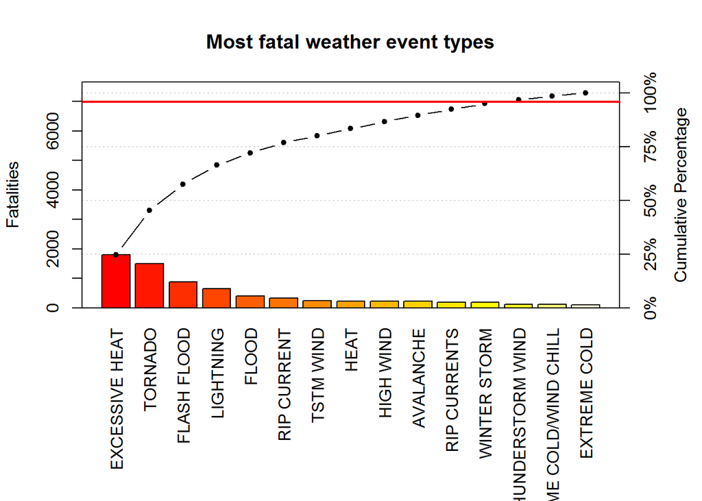

```r
abline(h=(sum(HI_F)*.8),col="red",lwd=2)
```

```r
pareto.chart(Top_HI_I, ylab = "Injuries", main = "Most injuring weather event types")
```

```
##
## Pareto chart analysis for Top_HI_I
##                     Frequency Cum.Freq. Percentage Cum.Percent.
##   TORNADO               20667     20667  39.316288     39.31629
##   FLOOD                  6758     27425  12.856219     52.17251
##   EXCESSIVE HEAT         6391     33816  12.158049     64.33056
##   LIGHTNING              4141     37957   7.877716     72.20827
##   TSTM WIND              3629     41586   6.903702     79.11197
##   FLASH FLOOD            1674     43260   3.184568     82.29654
##   THUNDERSTORM WIND      1400     44660   2.663318     84.95986
##   WINTER STORM           1292     45952   2.457862     87.41772
##   HURRICANE/TYPHOON      1275     47227   2.425522     89.84324
##   HEAT                   1222     48449   2.324697     92.16794
##   HIGH WIND              1083     49532   2.060267     94.22821
##   WILDFIRE                911     50443   1.733059     95.96127
##   HAIL                    713     51156   1.356390     97.31766
##   FOG                     712     51868   1.354488     98.67215
##   HEAVY SNOW              698     52566   1.327855    100.00000
```

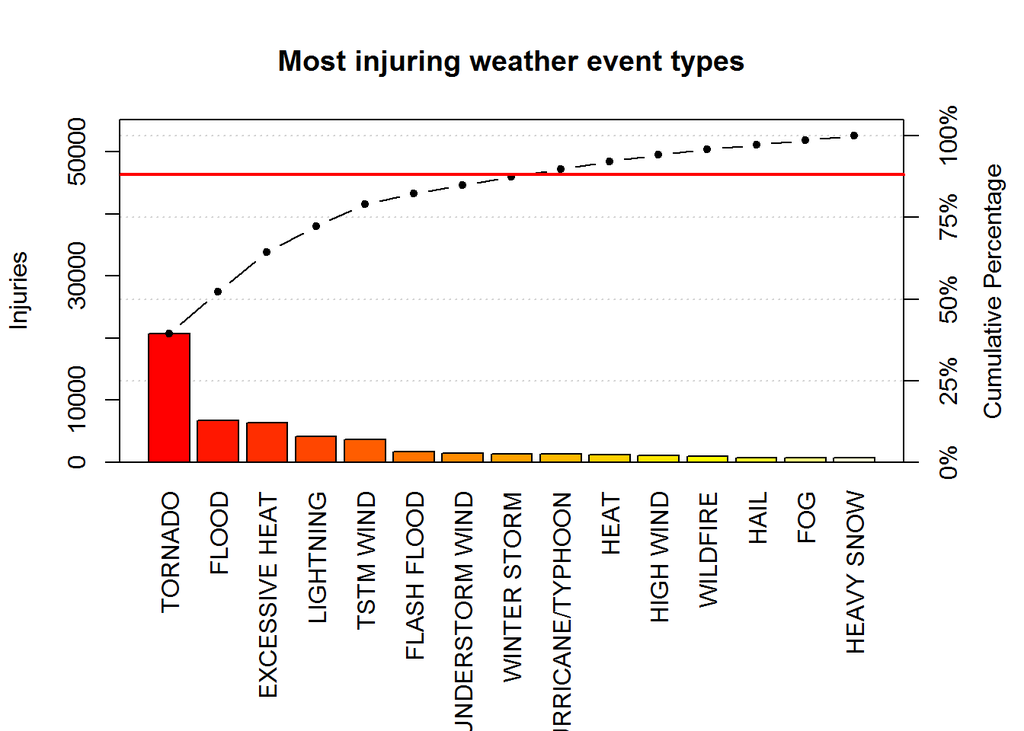

```r
abline(h=(sum(HI_I)*.8),col="red",lwd=2)
```

### The economic impact

We group the data per event type across the US and over time and we calculate the total dollar value of damage per event type to properties and crop. Inflation is not taken into consideration in this analysis.

```r
EconImp = StormData %>%
        group_by(EVTYPE) %>%
        summarise(totDMG = sum(PROPDMG) + sum(CROPDMG))
```

Using Pareto analysis to find the event types with highest economic impact in terms of total damage cost. Preparing the vector to create the pareto chart, and going to million USD values.

```r
EI_D = EconImp$totDMG / 10^6
names(EI_D) = EconImp$EVTYPE
```

Creating the Pareto chart for the economic impact. The red line is at 80% of the total cumulative impact whereas the Pareto chart and table are on the top 15 for readability.

```r
Top_EI_D = head(sort(EI_D, decreasing=TRUE), 15)
pareto.chart(Top_EI_D, ylab = "Damage (in MUSD)", main = "Highest damage cost weather event types")
```

```
##
## Pareto chart analysis for Top_EI_D
##                      Frequency Cum.Freq. Percentage Cum.Percent.
##   FLOOD             148919.612  148919.6 38.3920265     38.39203
##   HURRICANE/TYPHOON  71913.713  220833.3 18.5396210     56.93165
##   STORM SURGE        43193.541  264026.9 11.1354545     68.06710
##   TORNADO            24900.371  288927.2  6.4194076     74.48651
##   HAIL               17071.173  305998.4  4.4010115     78.88752
##   FLASH FLOOD        16557.106  322555.5  4.2684830     83.15600
##   HURRICANE          14554.229  337109.7  3.7521340     86.90814
##   DROUGHT            14413.667  351523.4  3.7158966     90.62403
##   TROPICAL STORM      8320.187  359843.6  2.1449748     92.76901
##   HIGH WIND           5881.422  365725.0  1.5162522     94.28526
##   WILDFIRE            5054.140  370779.2  1.3029759     95.58824
##   TSTM WIND           5031.942  375811.1  1.2972532     96.88549
##   STORM SURGE/TIDE    4642.038  380453.1  1.1967346     98.08223
##   THUNDERSTORM WIND   3780.985  384234.1  0.9747520     99.05698
##   ICE STORM           3657.909  387892.0  0.9430224    100.00000
```

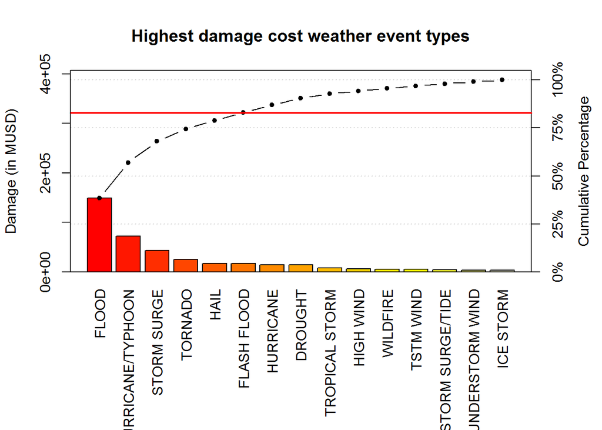

```r
abline(h=(sum(EI_D)*.8),col="red",lwd=2)
```